# Homework 4

Jonathan Bruner

2024-03-10

# Question 1: Chapter 6 Exercise 8 excluding parts (c) and (d)

In this exercise, we will generate simulated data, and will then use this data to perform best subset selection.

### (a) Use the **rnorm()* function to generate a predictor $X$ of length $n=100$, as well as a noise vector $\epsilon$ of length $n=100$.

```r
n = 100
X = rnorm(n)
e = rnorm(n)
```

### (b) Generate a response vector $Y$ of length $n=100$ according to the model where $\beta_0$, $\beta_1$, $\beta_2$, and $\beta_3$ are constants of your choice. $$Y=\beta_0+\beta_1X+\beta_2X^2+\beta_3X^3+\epsilon$$

```r
b_0 = sample(seq(1,20,1),1)
b_1 = sample(seq(1,20,1),1)
b_2 = sample(seq(1,20,1),1)
b_3 = sample(seq(1,20,1),1)

Y = b_0 + b_1*X + b_2*X^2 + b_3*X^3 + e
```

### (e) Now fit a lasso model to the simulated data, again using $X$, $X^2$, $\dots X^{10}$ as predictors. Use cross-validation to select the optimal value of $\lambda$. Create plots of the cross-validation error as a function of $\lambda$. Report the resulting coefficient estimates, and discuss the results obtained.

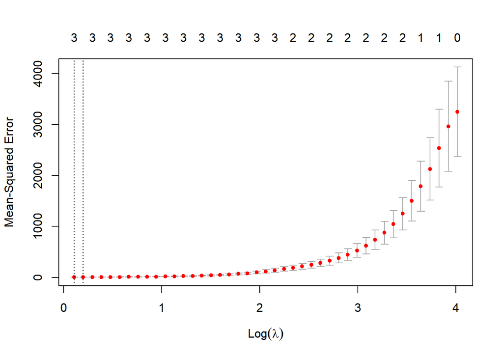

```r
x = model.matrix(Y~poly(X, degree=10, raw=TRUE))[,-1]

fit1_lasso = cv.glmnet(x, Y, alpha=1)
lasso.min.lambda = fit1_lasso$lambda.min

plot(fit1_lasso)
```

```r
coef(fit1_lasso)
```

```
## 11 x 1 sparse Matrix of class "dgCMatrix"
##                                           s1
## (Intercept)                         4.889570
## poly(X, degree = 10, raw = TRUE)1  17.206839
## poly(X, degree = 10, raw = TRUE)2   5.209256
## poly(X, degree = 10, raw = TRUE)3  10.951864
## poly(X, degree = 10, raw = TRUE)4   .
## poly(X, degree = 10, raw = TRUE)5   .
## poly(X, degree = 10, raw = TRUE)6   .
## poly(X, degree = 10, raw = TRUE)7   .
## poly(X, degree = 10, raw = TRUE)8   .
## poly(X, degree = 10, raw = TRUE)9   .
## poly(X, degree = 10, raw = TRUE)10  .
```

Based on the results the optimal value of $\lambda$ creates a degree 3 polynomial which matches the polynomial used to create the response variable.

### (f) Now generate a response vector $Y$ according to the model and perform best subset selection and the lasso. Discuss the results obtained. $$Y=\beta_0+\beta_7X^7+epsilon$$

```r
b_7 = sample(seq(1,20,1),1)

Y = b_0 + b_7*X^7 + e

fit1_bestsub = regsubsets(Y ~ x, data=NULL, nvmax=10)
bestsub.min.rss = which.max(fit1_bestsub$rss)

fit1_lasso = cv.glmnet(x, Y, alpha=1)
lasso.min.lambda = fit1_lasso$lambda.min

coef(fit1_bestsub, bestsub.min.rss)
```

```
##                        (Intercept) xpoly(X, degree = 10, raw = TRUE)7
##                           3.975649                          17.001564
```

```r
coef(fit1_lasso)
```

```
## 11 x 1 sparse Matrix of class "dgCMatrix"
##                                           s1
## (Intercept)                         8.384544
## poly(X, degree = 10, raw = TRUE)1   .
## poly(X, degree = 10, raw = TRUE)2   .
## poly(X, degree = 10, raw = TRUE)3   .
## poly(X, degree = 10, raw = TRUE)4   .
## poly(X, degree = 10, raw = TRUE)5   .
## poly(X, degree = 10, raw = TRUE)6   .
## poly(X, degree = 10, raw = TRUE)7  16.404607
## poly(X, degree = 10, raw = TRUE)8   .
## poly(X, degree = 10, raw = TRUE)9   .
## poly(X, degree = 10, raw = TRUE)10  .
```

Both models used the intercept and the degree 7 polynomial term, this matches with the function that generated $Y$.

# Question 2

The *diabetes.csv* file on D2L contains concentrations of 131 metabolites measured from a sample of 198 patients with diabetes. One of the metabolites, creatinine, is an indicator of kidney function. This problem will investigate the problem of predicting creatinine using the values of the other 130 metabolites.

```r
dat2 = read.csv('diabetes.csv')
```

### (a) Divide the data set into a training and test set. Your training set should consist of the first 150 observations while the test set is made up of the remaining observations.

```r
x_train = model.matrix(creatinine ~ ., dat2[1:150,])[,-1]
x_test = model.matrix(creatinine ~ ., dat2[-1:-150,])[,-1]
y_train = dat2[1:150, which(names(dat2) == 'creatinine')]
y_test = dat2[-1:-150, which(names(dat2) == 'creatinine')]
```

### (b) Using the training data, fit a ridge regression model to predict creatinine using the other metabolites. Choose the value of lambda using cross-validation. What value of lambda is chosed?

```r
fit2.ridge = cv.glmnet(x_train,y_train, alpha=0)
ridge.min.lambda = fit2.ridge$lambda.min
```

I have chosen the $\lambda$ value of 0.588628

### (c) Using the training data, fit a lasso regression model to predict creatinine using the other metabolites. Choose the value of lambda using cross-validation. What value of lambda is chosen?

```r
fit2.lasso = cv.glmnet(x_train,y_train, alpha=1)
lasso.min.lambda = fit2.lasso$lambda.min
```

I have chosen the $\lambda$ value of 0.0221615

### (d) How many of the regression coefficients from the lasso model in part (c) shrink to zero?

```r
coef(fit2.lasso, s=lasso.min.lambda)
```

```
## 131 x 1 sparse Matrix of class "dgCMatrix"
##                        s1
## (Intercept)  6.938814e+01
## var_1       -2.990644e-05
## var_2        5.843888e-03
## var_3        7.185440e-03
## var_4       -1.289581e-02
## var_5        1.410043e-03
## var_6        1.046559e-02
## var_7        .
## var_8        .
## var_9        .
## var_10       7.652615e-03
## var_11       .
## var_12       6.916292e-03
## var_13       .
## var_14       5.579701e-03
## var_15      -1.202790e-02
## var_16       2.797631e-01
## var_17       .
## var_18       .
## var_19       .
## var_20       .
## var_21       2.820404e-03
## var_22       .
## var_23       .
## var_24       1.006380e-03
## var_25       .
## var_26       8.112947e-02
## var_27       .
## var_28       .
## var_29       .
## var_30       .
## var_31       .
## var_32       .
## var_33       .
## var_34      -1.963004e-02
## var_35       .
## var_36       .
## var_37       .
```

[output cut: 78 more lines]

```
## var_116      .
## var_117      .
## var_118      1.227600e-02
## var_119     -1.458717e-01
## var_120      1.323596e+00
## var_121      .
## var_122      .
## var_123     -1.568244e+01
## var_124      .
## var_125      .
## var_126      2.180612e+01
## var_127      .
## var_128      .
## var_129      5.975614e-02
## var_130      .
```

```r
len = length(which(coef(fit2.lasso, s=lasso.min.lambda) == 0))
```

There are 95 coefficients that shrunk to zero.

### (e) Using the training data, fit a PCR model to predict creatinine using the other metabolites. Use cross-validation to choose the number of principal components. Explain your choice (there might be more than one correct answer here).

```r
fit2.pcr = pcr(y_train ~ x_train, scale=TRUE, validation='CV')
summary(fit2.pcr)
```

```
## Data:    X dimension: 150 130
##  Y dimension: 150 1
## Fit method: svdpc
## Number of components considered: 130
##
## VALIDATION: RMSEP
## Cross-validated using 10 random segments.
##        (Intercept)  1 comps  2 comps  3 comps  4 comps  5 comps  6 comps
## CV           6.148    6.155    6.046    4.910    3.969    3.681    2.967
## adjCV        6.148    6.152    6.051    4.917    3.945    3.647    2.842
##        7 comps  8 comps  9 comps  10 comps  11 comps  12 comps  13 comps
## CV       2.711    2.697    2.718     2.661     2.671     2.651     2.651
## adjCV    2.676    2.668    2.697     2.640     2.654     2.635     2.630
##        14 comps  15 comps  16 comps  17 comps  18 comps  19 comps  20 comps
## CV        2.597     2.572     2.518     2.438     2.323     2.282     2.261
## adjCV     2.561     2.558     2.508     2.418     2.275     2.235     2.227
##        21 comps  22 comps  23 comps  24 comps  25 comps  26 comps  27 comps
## CV        2.308     2.347     2.352     2.303     2.202     2.132     2.077
## adjCV     2.263     2.338     2.314     2.312     2.172     2.094     2.029
##        28 comps  29 comps  30 comps  31 comps  32 comps  33 comps  34 comps
## CV        2.067     2.049     2.067     2.051     2.058     2.042     1.990
## adjCV     2.031     1.999     2.022     2.017     2.036     2.022     1.985
##        35 comps  36 comps  37 comps  38 comps  39 comps  40 comps  41 comps
## CV        1.904     1.964     1.984     2.001     1.971     1.951     1.926
## adjCV     1.833     1.911     1.930     1.954     1.940     1.908     1.839
##        42 comps  43 comps  44 comps  45 comps  46 comps  47 comps  48 comps
## CV        1.811     1.746     1.711     1.642     1.585     1.472     1.455
## adjCV     1.747     1.689     1.686     1.585     1.538     1.417     1.400
##        49 comps  50 comps  51 comps  52 comps  53 comps  54 comps  55 comps
## CV        1.392     1.396     1.360     1.354     1.355     1.352     1.356
## adjCV     1.343     1.349     1.313     1.309     1.314     1.312     1.322
##        56 comps  57 comps  58 comps  59 comps  60 comps  61 comps  62 comps
## CV        1.359      1.34     1.291     1.315     1.330     1.323     1.336
## adjCV     1.319      1.31     1.263     1.288     1.296     1.301     1.317
##        63 comps  64 comps  65 comps  66 comps  67 comps  68 comps  69 comps
## CV        1.313     1.308     1.273     1.273     1.260     1.240     1.236
## adjCV     1.266     1.266     1.235     1.237     1.218     1.198     1.188
##        70 comps  71 comps  72 comps  73 comps  74 comps  75 comps  76 comps
## CV        1.159     1.129     1.130     1.161     1.102     1.077     1.128
## adjCV     1.125     1.091     1.093     1.119     1.067     1.046     1.092
```

[output cut: 74 more lines]

```
##          106 comps  107 comps  108 comps  109 comps  110 comps  111 comps
## X            99.99     100.00     100.00     100.00     100.00     100.00
## y_train      99.91      99.91      99.92      99.94      99.94      99.94
##          112 comps  113 comps  114 comps  115 comps  116 comps  117 comps
## X           100.00     100.00     100.00     100.00     100.00     100.00
## y_train      99.94      99.94      99.95      99.95      99.95      99.95
##          118 comps  119 comps  120 comps  121 comps  122 comps  123 comps
## X           100.00     100.00     100.00     100.00     100.00     100.00
## y_train      99.95      99.95      99.95      99.95      99.95      99.95
##          124 comps  125 comps  126 comps  127 comps  128 comps  129 comps
## X           100.00     100.00     100.00     100.00     100.00     100.00
## y_train      99.96      99.96      99.96      99.96      99.96      99.97
##          130 comps
## X           100.00
## y_train      99.98
```

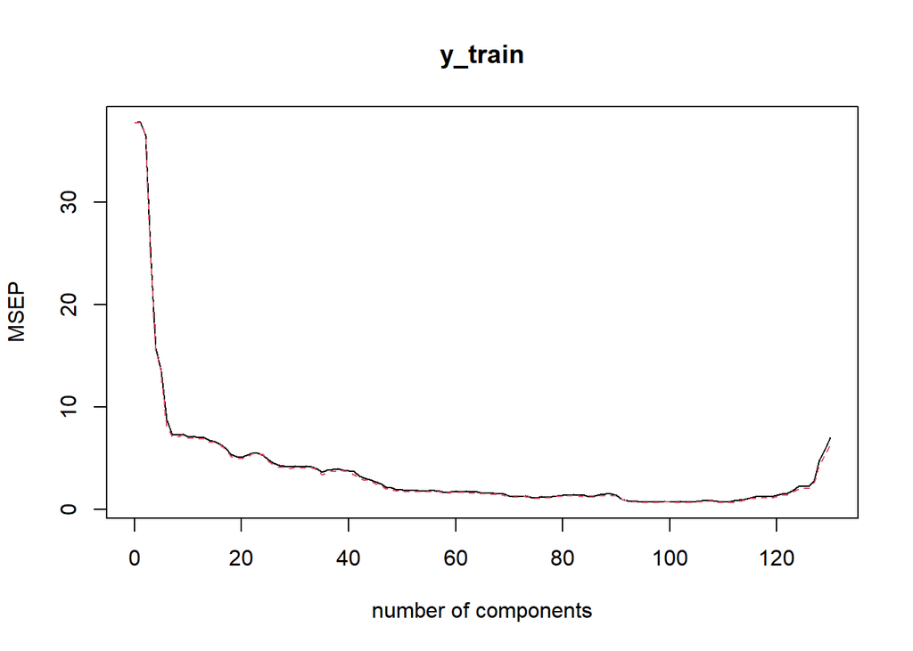

```r
validationplot(fit2.pcr, val.type='MSEP')
```

I choose 7 principal components. The reason for this choice is according to the summary the MSE seems to level out around 6-7, as well as the percent of variance of Y explained. Using the plot I can see that around the 5-10 mark there should be an “elbow” in the data, which tells me the more principal components I add the less I decrease my MSE.

### (f) Calculate the MSE on the test data for each of the three models.

```r
pred2.ridge = predict(fit2.ridge, s = ridge.min.lambda, newx = x_test)
ridge.mse = mean((pred2.ridge - y_test)^2)

pred2.lasso = predict(fit2.lasso, s = lasso.min.lambda, newx = x_test)
lasso.mse = mean((pred2.lasso - y_test)^2)

pred2.pcr = predict(fit2.pcr, x_test, ncomp = 7)
pcr.mse = mean((pred2.pcr - y_test)^2)
```

Ridge Regression MSE: 1.421433

Lasso Regression MSE: 0.3495762

Principal Component Regression MSE: 5.1173233

### (g) Which model performed the best? Explain your answer.

From the MSE values above it appears the Lasso Regression performed best.

# Question 3: Chapter 6 Exercise 2

For parts (a) through (c), indicate which of *i*. through *iv*. is correct. Justify your answer.

### (a) The lasso, relative to least squares is:

#### (*i*). More flexible and hence will give improved prediction accuracy when its increase in bias is less than its decrease in variance.

#### (*ii*). More flexible and hence will give improved prediction accuracy when its increase in variance is less than its decrease in bias.

#### (*iii*). Less flexible and hence will give improved prediction accuracy when its increase in bias is less than its decrease in variance.

#### (*iv*). Less flexible and hence will give improved prediction accuracy when its increase in variance is less than its decrease in bias.

For Lasso, relative to least squares, I believe *iv* is correct. Lasso is less flexible than least squares since we are forcing some constants to zero, hence getting rid of predictors. As we remove predictors we will be increasing our variance while we are decreasing our bias, and we will stop whenever our increase in variance jumps above our decrease in bias. This means that removing that next predictor greatly increases our variance, which tells us it is an important predictor.

### (b) Repeat (a) for ridge regression relative to least squares.

For Ridge, relative to least squares, I again believe *iv* is correct. As we increase $\lambda$ our estimates go to zero, hence making this model less flexible than least squares. Similarly to above as our bias decreases our variance increases.

### (c) Repeat (a) for non-linear methods relative to least squares.

For non-linear methods, relative to least squares, I believe *i* is correct. As we increase the degree of our model we increase our bias, but we can also decrease our variance. We should stop whenever our increase in bias is less than the decrease in variance. This is because if we add another high order term we greatly increase our bias, however our variance doesn’t decrease very much which leads to over fitting.